# Introdução à Valoração: O Valor do Dinheiro no Tempo

Ross et al. (2022), capítulo 05

Marcelo S. Perlin

EA-UFRGS

02/09/2026

# O valor do dinheiro no tempo

## Introdução

> O Valor do Dinheiro no Tempo (VDT) é um conceito fundamental em finanças que reconhece que o dinheiro disponível hoje vale mais do que a mesma quantia no futuro.

Isso se deve a diversas razões, como:

- a possibilidade de investir o dinheiro e obter retornos financeiros
- inflação que erode o poder de compra do dinheiro ao longo do tempo
- preferência natural das pessoas por receber o dinheiro agora em vez de esperar no futuro.

## Fatores que Influenciam o VDT

O valor do dinheiro no tempo é influenciado por três fatores principais:

**Taxa de Juros**

A taxa de juros é o custo de tomar dinheiro emprestado ou o retorno de investir dinheiro. A referência de taxa de juros no Brasil é a SELIC, hoje em 14,00% ao ano.

**Inflação**

Representa o aumento de preços de uma cesta de produtos. O principal índice de inflação é o IPCA (Índices de Preços ao Consumidor Amplo). A última variação do IPCA foi de 0,07% ao mês (0,84% ao ano)

**Tempo (ou horizonte de investimento)**

Quanto mais tempo o dinheiro for investido, maior será o retorno cumulativo e, consequentemente, maior será o valor final.

# Valor Futuro

## Conceito

> O valor futuro é o valor no futuro de um fluxo de caixa hoje

$$VF = VP*(1+r)^T$$

$VF$ - Valor futuro

$VP$ - Valor presente

$r$ - taxa de juros

$T$ - Número de períodos à frente

## Investindo por um período

> Suponhamos que você invista R$ 1.000,00 na poupança do Banco do Brasil, a qual paga atualmente 8,34% ao ano. Qual será o valor em poupança após:
- 1 anos?
- 5 anos?
- 15 anos?
- Em 1 ano, você terá R$ 1.083,40. Esse valor equivale ao seu valor original de R$ 1.000,00 mais R$ 83,40 de juros que você ganhou.
- Em 5 anos, o investimento terá crescido ao valor de R$ 1.492,63
- Em 15 ano você terá R$ 3.325,50. Esses R$ 3.325,50 equivalem ao seu valor original de R$ 1.000,00 mais R$ 2.325,50 de juros que você ganhou.

## Juros composto e simples

> **Juros composto** é aquela onde juros incide sobre juros. É a forma mais comum no mundo real.

## Exemplo Tabela

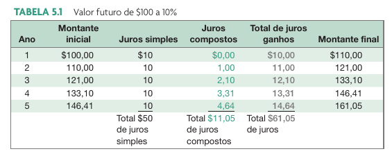

Extraído de Ross et al. (2022), página 126

## Exemplo Gráfico

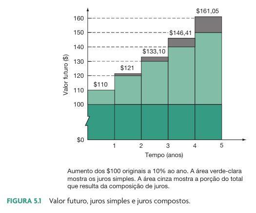

Extraído de Ross et al. (2022), página 127

## O impacto do tipo de juro

Valor investimento inicial = R$ 1.000,00

Taxa de juros = 10,00%

Número de anos = 50

**Resultado**:

Valor Futuro (juros simples) = R$ 6.000,00

Valor Futuro (juros compostos) = R$ 117.390,85

## Juros do SP500

> Se um investidor colocasse $10.000 no índice SP500 em 01/01/1950, qual seria o valor em 01/09/2026, após 76.7 anos de investimento?

O montante seria de $4.570.714, com uma capitalização nominal (com inflação) de 8,31% ao ano.

## Juros do Tesouro Direto

# Valor presente

## Valor presente de um único período

> Dada uma taxa de desconto, o valor presente nos diz qual o valor justo hoje, de um valor futuro.

$$VP = \frac{VF}{(1+r)^T}$$

$VP$ - valor presente

$VF$ - valor futuro

$r$ - taxa de juros

$T$ - número de períodos

## Exemplo VP

> Imagine que daqui a 5 anos terá que pagar uma dívida a vista com valor nominal de R$ 5.000,00. Qual deve ser o valor investido em poupança (r = 8,34% ao ano) hoje para ter esse montante na conta em 5 anos?
- Ao investir R$ 3.349,79 na poupança hoje, em 5 anos terás R$ 5.000,00 disponíveis em conta.

# Retorno em investimentos

## Introdução

- Todo investimento tem
  1. Custo de entrada ($FC_0$)
  2. fluxos de caixa positivos no futuro
     - Proventos: dividendos ou cupons ($FC_t$)
     - Venda de ação/título de dívida ($FC_T$)

$$R = \frac{FC_T + \sum ^T _{t=1} FC_t}{FC_0} - 1$$

## Fluxo de Caixa (EGIE3)

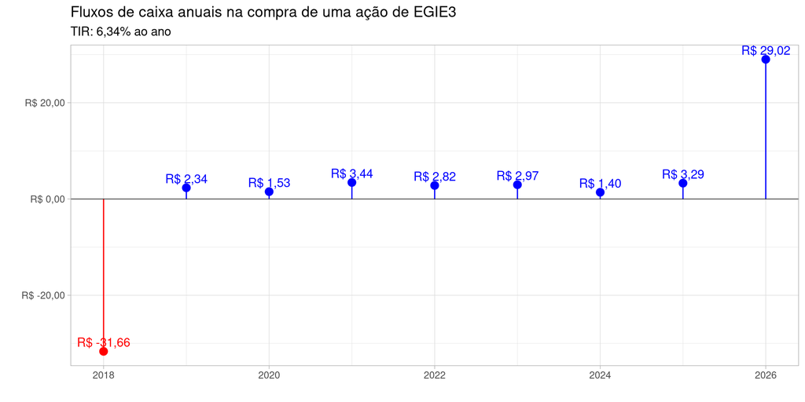

# O caso [Betina](https://www.youtube.com/watch?v=guM8PhzVpF8)

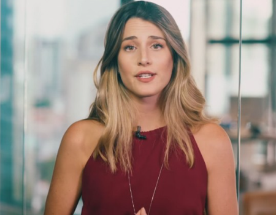

> Oi, meu nome é Betina, tenho 22 anos e um milhão e 42 mil de patrimônio acumulado. Comecei com 19 anos e 1500 R$…”

## A matemática da Betina não fecha..

O valor de R$ 1.500,00 investido por 3 anos transforma-se em R$ 1.000.043,00, o que é equivalente a 19,80% ao mês (773,59%) ao ano). Ao longo de 10 anos, teremos:

O investimento de Betina

| Anos | Valor |
| --- | --- |
| 0 | R$ 1.500,00 |
| 1 | R$ 13.103,89 |
| 2 | R$ 114.474,71 |
| 3 | R$ 1.000.043,00 |
| 4 | R$ 8.736.305,50 |
| 5 | R$ 76.319.752,11 |
| 6 | R$ 666.724.001,23 |
| 7 | R$ 5.824.454.109,93 |
| 8 | R$ 50.882.022.569,93 |
| 9 | R$ 444.501.780.243,15 |
| 10 | R$ 3.883.136.374.301,74 |

## Referências

Ross, Stephen, Randolph Westerfield, Bradford Jordan, et al. 2022. *Fundamentos de Administração Financeira*. Bookman Editora.